# R-code for ‘Tolerability of atovaquone-proguanil application in common buzzards’

Anja Wiegmann, Tony Rinaud, Meinolf Ottensmann, Oliver Krüger, Andrea Springer, Marko Legler, Michael Fehr, Christina Strube and Nayden Chakarov

This document provides all the `R code` used in our paper. Both the Rmarkdown file and the data can be downloaded from the accompanying GitHub repository on (https://github.com/TonyRinaud/malarone_tolerability) as a zip archive containing all the files. We recommend to download or clone this [GitHub repository](https://github.com/TonyRinaud/malarone_tolerability) in order to access the documentation together with all the files that are needed to repeat analyses shown in this document. Just click on the link above and then on the green box `Clone or download`. In order to function properly, the same structure of folders must be kept. If you have any questions, don’t hesitate to contact tony.rinaud[at]uni-bielefeld.de or m.ottensmann[at]uni-bielefeld.de

In order to repeat analyses presented in this document, the following packages are required.

```r
## Load packages
## -----------------------------------------------------------------------------
easypackages::libraries(
  "tidyverse", "lme4", "chron", "patchwork",
  "magrittr", "readr", "EnvStats", "sjPlot", "egg","ggplot2","dplyr","RVAideMemoire","car","lsmeans")
```

## Loading raw datasets

- `Malarone® experiment`

Experimental study comprising data from 299 nestlings that were either treated with Malarone® or water. An additional subset comprises individuals that received no treatment and were therefore only exposed to repeated routine sampling and handling.

```r
## Read and format raw data: (saved raw data with "." as decimal operator)
## -----------------------------------------------------------------------------
malarone.data <- readr::read_delim(
  file = 'data/malarone_tolerability.csv', delim = ";", col_types = "fffffffinnnnnnnnnnnffff") %>%
  mutate(Treatment = case_when(Treatment == "Control" ~ "control",
                               Treatment == "Water" ~ "water",
                               Treatment == "Malarone" ~ "Malarone®")) %>%
  mutate(Treatment = factor(Treatment, levels = c("control","water","Malarone®"))) %>%
  ## Scaling continuous variables
  mutate(delta_body_condition = scale(delta_body_condition)) %>%
  mutate(body_condition.1 = scale(body_condition.1)) %>%
  mutate(body_condition.2 = scale(body_condition.2)) %>%
  mutate(growth_rate = scale(growth_rate))
```

- `Bloodchemistry data`

```r
bloodchem.data <- read.csv2(file = "data/bloodchemistry_data.csv",sep = ";",dec = ".") %>%
  mutate(Ring = as.character(Ring)) %>%
  mutate(BCI = as.numeric(BCI)) %>%
  mutate(Dosage = as.numeric(Dosage)) %>%
  mutate(Treatment = factor(Treatment,
                            levels = c("Pre-Control", "Post-Control", "Pre-Mal", "Post-Mal"))) %>%
  mutate(doy = lubridate::yday(Date))
names(bloodchem.data)[names(bloodchem.data) == "Lprev"] <- "Leucocytozoon"

## Some gGT values are at boundaries, set those to 5
## -----------------------------------------------------------------------------
bloodchem.data$GGT[bloodchem.data$GGT == "<5"] <- 5
bloodchem.data$GGT <- as.numeric(bloodchem.data$GGT)

## Summarise sample sizes
## -----------------------------------------------------------------------------
pander::pandoc.table(table(bloodchem.data$Treatment))
```

```
##
## -------------------------------------------------
##  Pre-Control   Post-Control   Pre-Mal   Post-Mal
## ------------- -------------- --------- ----------
##      38             11          11         11
## -------------------------------------------------
```

## Analyses

### `Experimental data`

#### Data summary

```r
## Sample size per treatment and year
with(malarone.data, table(Year, Treatment))
```

```
##       Treatment
## Year   control water Malarone®
##   2020      35    41        41
##   2016      39     0         0
##   2018      46    12        12
##   2019      30     0        43
```

```r
quantile(malarone.data$avg_age)
```

```
##       0%      25%      50%      75%     100%
## 10.74546 20.49167 23.74707 26.53507 37.01213
```

```r
quantile(malarone.data$days_resample)
```

```
##   0%  25%  50%  75% 100%
##    4    6    7    8   25
```

- Visualise distribution of age at sampling for each treatment level

```r
## Create data frame with data on both sampling occasion
## -----------------------------------------------------------------------------
summary.df <- data.frame(
  Treatment = rep(malarone.data$Treatment, 2),
  Age = c(malarone.data$Age.1, malarone.data$Age.2),
  Ring = rep(malarone.data$Ring, 2),
  Wing = c(malarone.data$Wing.1, malarone.data$Wing.2),
  Weight = c(malarone.data$Weight.1, malarone.data$Weight.2),
  Sampling = rep(c("First sample", "Second sample"), each = 299),
  Sex = rep(malarone.data$Sex,2))

## Summarise Age at sampling
## -----------------------------------------------------------------------------
summary.df %>%
  group_by(Treatment, Sampling) %>%
  summarise(MEAN = mean(Age),
            SD = sd(Age),
            Min = min(Age),
            Max = max(Age),
            LCL = quantile(Age, 0.025),
            UCL = quantile(Age, 0.975))
```

```
## # A tibble: 6 x 8
## # Groups:   Treatment [3]
##   Treatment Sampling       MEAN    SD   Min   Max   LCL   UCL
##   <fct>     <chr>         <dbl> <dbl> <dbl> <dbl> <dbl> <dbl>
## 1 control   First sample   18.2  5.54  7.06  34.8  8.79  30.7
## 2 control   Second sample  28.1  6.30 13.0   41.6 17.6   40.3
## 3 water     First sample   19.8  4.30 11.2   28.5 12.7   27.6
## 4 water     Second sample  26.7  4.53 18.1   36.2 19.4   35.6
## 5 Malarone® First sample   21.1  3.75 11.7   29.2 13.3   27.6
## 6 Malarone® Second sample  28.1  4.24 19.2   39.2 20.8   35.6
```

```r
## Summarise Weight at sampling
## -----------------------------------------------------------------------------
summary.df %>%
  group_by(Treatment, Sampling) %>%
  summarise(MEAN = mean(Weight),
            SD = sd(Weight),
            Min = min(Weight),
            Max = max(Weight),
            LCL = quantile(Weight, 0.025),
            UCL = quantile(Weight, 0.975))
```

```
## # A tibble: 6 x 8
## # Groups:   Treatment [3]
##   Treatment Sampling       MEAN    SD   Min   Max   LCL   UCL
##   <fct>     <chr>         <dbl> <dbl> <dbl> <dbl> <dbl> <dbl>
## 1 control   First sample   524.  161.   160   910  226.  800
## 2 control   Second sample  706.  137.   260  1000  351.  963.
## 3 water     First sample   574.  139.   355   885  356.  856
## 4 water     Second sample  714.  120.   395   960  468.  932.
## 5 Malarone® First sample   639.  129.   335   990  396.  860
## 6 Malarone® Second sample  768.  103.   460  1000  562.  952.
```

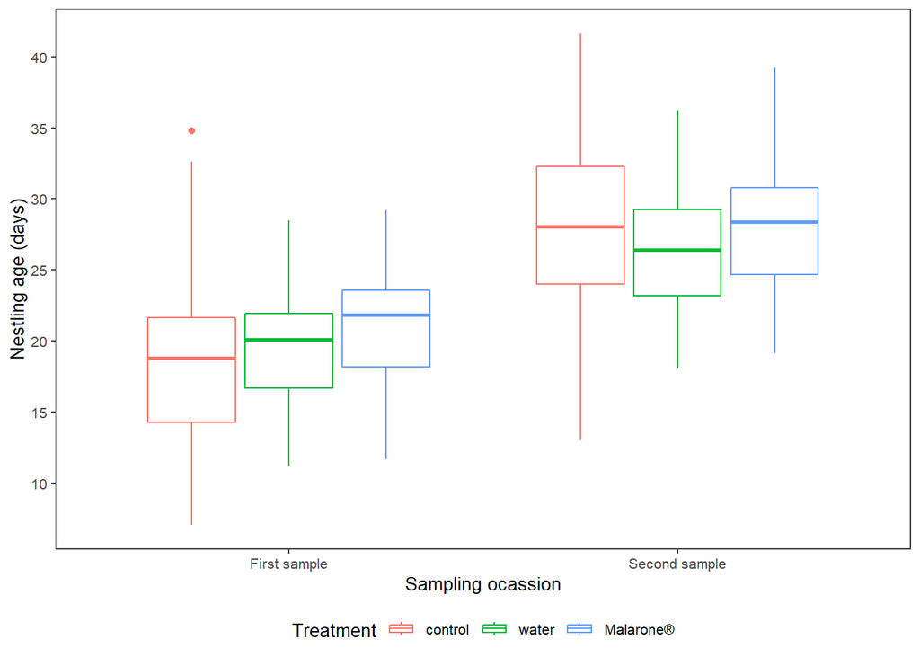

```r
## Plot distributions
## -----------------------------------------------------------------------------
ggplot(summary.df, aes(x = Sampling, y = Age, col = Treatment)) +
  theme_article(base_size = 10) +
  theme(legend.position = "bottom") +
  geom_boxplot(position = position_dodge2(width = .5)) +
  scale_y_continuous(breaks = seq(5, 40, 5)) +
  ylab("Nestling age (days)") +
  xlab("Sampling ocassion")
```

- Visualise regression of body weight on wing length as measure of body condition

To explore the potential of treatment-specific effects on growth parameters, we next visualise the regression of body weight on wing length. For comparison, we include reference data that has been obtained for nestlings of known hatching dates (Bijlsma 1999, Limosa 72, Appendices 1 - 2).

```r
## read reference dataset
## -----------------------------------------------------------------------------
bijlsma <- read.csv("data/bijlsma_1999_Limosa_72.csv")
head(bijlsma)
```

```
##   age  sex wing weight                  Source
## 1   0 Male 1.79   45.1 Bijlsma 1999, Limosa 72
## 2   1 Male 1.99   58.1 Bijlsma 1999, Limosa 72
## 3   2 Male 2.21   69.2 Bijlsma 1999, Limosa 72
## 4   3 Male 2.44   68.4 Bijlsma 1999, Limosa 72
## 5   4 Male 2.72  108.8 Bijlsma 1999, Limosa 72
## 6   5 Male 2.89  124.8 Bijlsma 1999, Limosa 72
```

```r
tail(bijlsma)
```

```
##     age    sex  wing weight                  Source
## 97   45 Female 32.70  855.0 Bijlsma 1999, Limosa 72
## 98   46 Female 33.28  888.0 Bijlsma 1999, Limosa 72
## 99   47 Female 33.23  811.2 Bijlsma 1999, Limosa 72
## 100  48 Female 33.60  875.0 Bijlsma 1999, Limosa 72
## 101  49 Female 34.40  856.7 Bijlsma 1999, Limosa 72
## 102  50 Female 35.00  825.0 Bijlsma 1999, Limosa 72
```

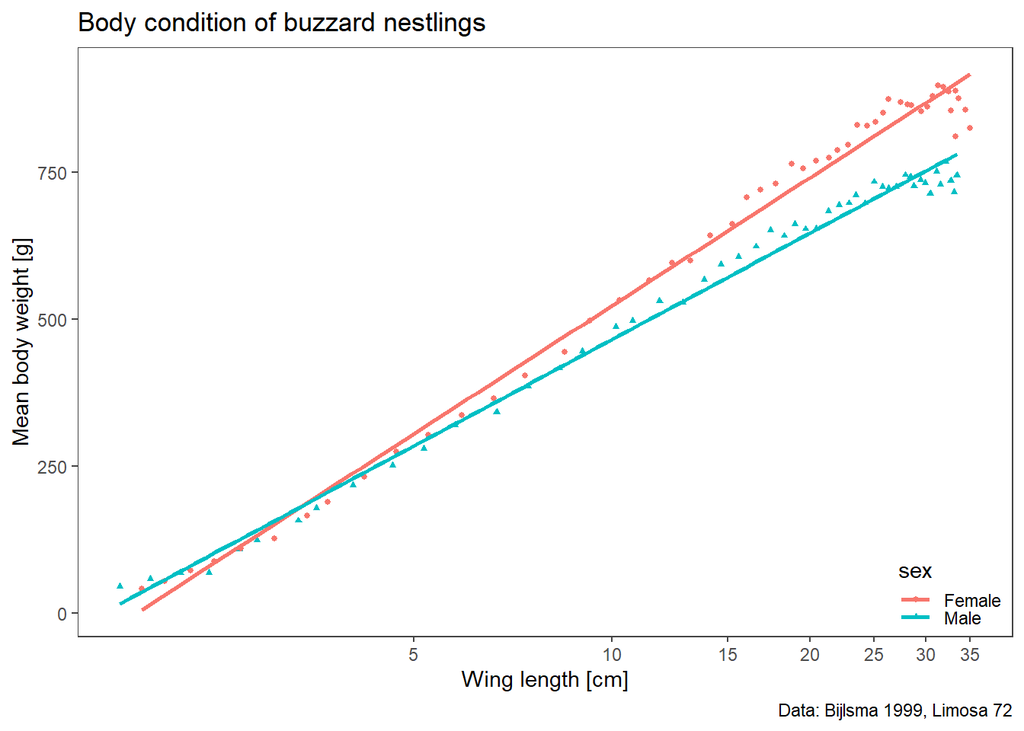

```r
## visualise sex-specific condition curves
## -----------------------------------------------------------------------------
ggplot(bijlsma, aes(x = wing, y =  weight, shape = sex, col = sex)) +
  geom_point(size = 1, na.rm = T) +
  geom_smooth(method = "lm", na.rm = T, formula = "y ~ x", se = F) +
  theme_article() +
  theme(legend.position = c(1,0),
        legend.justification = c(1,0)) +
  scale_x_log10(breaks = seq(0, 35, 5)) +
  ylab("Mean body weight [g]") +
  xlab("Wing length [cm]") +
  labs(title = "Body condition of buzzard nestlings",
       caption = "Data: Bijlsma 1999, Limosa 72")
```

```r
## obtain formula for age-specific regression lines
## -----------------------------------------------------------------------------
female <- lm(weight ~ log10(wing), data = bijlsma[bijlsma$sex == "Female",])
summary(female)
```

```
##
## Call:
## lm(formula = weight ~ log10(wing), data = bijlsma[bijlsma$sex ==
##     "Female", ])
##
## Residuals:
##     Min      1Q  Median      3Q     Max
## -92.207 -18.469   3.535  21.872  46.489
##
## Coefficients:
##             Estimate Std. Error t value Pr(>|t|)
## (Intercept)  -201.18      12.78  -15.75   <2e-16 ***
## log10(wing)   724.31      10.73   67.51   <2e-16 ***
## ---
## Signif. codes:  0 '***' 0.001 '**' 0.01 '*' 0.05 '.' 0.1 ' ' 1
##
## Residual standard error: 29.81 on 49 degrees of freedom
## Multiple R-squared:  0.9894, Adjusted R-squared:  0.9891
## F-statistic:  4558 on 1 and 49 DF,  p-value: < 2.2e-16
```

```r
female$coefficients
```

```
## (Intercept) log10(wing)
##   -201.1760    724.3095
```

```r
male <- lm(weight ~ log10(wing), data = bijlsma[bijlsma$sex == "Male",])
summary(male)
```

```
##
## Call:
## lm(formula = weight ~ log10(wing), data = bijlsma[bijlsma$sex ==
##     "Male", ])
##
## Residuals:
##     Min      1Q  Median      3Q     Max
## -62.211 -15.117   0.275  17.823  41.224
##
## Coefficients:
##             Estimate Std. Error t value Pr(>|t|)
## (Intercept) -136.301      9.521  -14.31   <2e-16 ***
## log10(wing)  601.853      8.138   73.96   <2e-16 ***
## ---
## Signif. codes:  0 '***' 0.001 '**' 0.01 '*' 0.05 '.' 0.1 ' ' 1
##
## Residual standard error: 22.34 on 48 degrees of freedom
##   (1 observation deleted due to missingness)
## Multiple R-squared:  0.9913, Adjusted R-squared:  0.9911
## F-statistic:  5470 on 1 and 48 DF,  p-value: < 2.2e-16
```

```r
male$coefficients
```

```
## (Intercept) log10(wing)
##   -136.3015    601.8529
```

- Establish growth curves for all treatment x sex combinations (n=6)

```r
## define all combinations
## -----------------------------------------------------------------------------
combinations <- data.frame(Treatment = rep(c("control", "Malarone®", "water"), each = 2),
                           Sex = rep(c("Female", "Male"), 3))

## fit models
## -----------------------------------------------------------------------------
models <- lapply(1:nrow(combinations), function(x) {
  model <- lmer(Weight ~ log10(Wing) + (1|Ring),
                data = filter(summary.df,
                              Treatment == combinations$Treatment[x],
                              Sex == combinations$Sex[x]))
  data.frame(Treatment = combinations$Treatment[x],
             Sex = combinations$Sex[x],
             Intercept = summary(model)$coefficients[1,1],
             Slope = summary(model)$coefficients[2,1],
             R2.marg = performance::model_performance(model)[4],
             R2.cond = performance::model_performance(model)[3])

}) %>%
  do.call("rbind",.)
models
```

```
##   Treatment    Sex Intercept    Slope R2_marginal R2_conditional
## 1   control Female -308.9716 818.9989   0.8596137      0.9050312
## 2   control   Male -225.1288 691.4430   0.7653171      0.8852781
## 3 Malarone® Female -415.1732 936.3559   0.7910488      0.8850544
## 4 Malarone®   Male -278.2952 762.6479   0.6601428      0.7739297
## 5     water Female -359.2878 887.8414   0.8229464      0.9133084
## 6     water   Male -252.4718 720.1278   0.6889483      0.8682060
```

- Adding reference data to raw data points from the current study

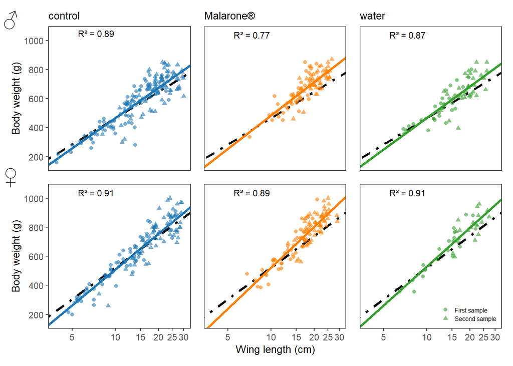

```r
## Male control
## -----------------------------------------------------------------------------
m.c <-
  ggplot(filter(summary.df, Sex == "Male", Treatment == "control"),
         aes(x = Wing, y =  Weight)) +
  geom_abline(intercept = male$coefficients[1], slope = male$coefficients[2],
              lty = 4, size = 1.1) +
  geom_abline(intercept = models$Intercept[2], slope = models$Slope[2],
              lty = 1, size = 1.1, col = "#1F78B4") +
  geom_point(size = 1.5, alpha = .6, aes(shape = Sampling), col = "#1F78B4") +
  guides(col = "none") +
  theme_article() +
  theme(legend.position = "none",
        plot.subtitle=element_text(size=10),
        axis.title = element_text(size=10),
        axis.text.x = element_blank(),
        axis.title.x = element_blank(),
        axis.ticks.x = element_blank()) +
  ylab("Body weight (g)") +
  labs(subtitle = "control") +
  scale_y_continuous(breaks = seq(0, 1000, 200), limits = c(150, 1050)) +
  scale_x_log10(breaks = seq(0, 30, 5), limits = c(3.8, 30.1)) +
  geom_text(data = data.frame(Wing = Inf, Weight = Inf, Treatment = "control"),
            label = paste("R² =", round(models$R2_conditional[2],2)),
            hjust = 3.1, vjust = 1.5, col = "Black", size= 3) +
  geom_text(data = data.frame(Wing = 3.9, Weight = Inf, Treatment = "control"),
            label = "\U2642", hjust = 3.5, vjust = 0, col = "Black", size = 7) +
  coord_cartesian(clip = 'off')

## Male Malarone®
## -----------------------------------------------------------------------------
m.m <-
  ggplot(filter(summary.df, Sex == "Male", Treatment == "Malarone®"),
         aes(x = Wing, y =  Weight)) +
  geom_abline(intercept = male$coefficients[1], slope = male$coefficients[2],
              lty = 4, size = 1.1) +
  geom_abline(intercept = models$Intercept[4], slope = models$Slope[4],
              lty = 1, size = 1.1, col = "#FF7F00") +
  geom_point(size = 1.5, alpha = .6, aes(shape = Sampling), col = "#FF7F00") +
  guides(col = "none") +
  labs(subtitle = "Malarone®") +
  theme_article() +
  theme(legend.position = "none",
        plot.subtitle=element_text(size=10),
        axis.text = element_blank(),
        axis.title = element_blank(),
        axis.ticks = element_blank()) +
  scale_y_continuous(breaks = seq(0, 1000, 200), limits = c(150, 1050)) +
  scale_x_log10(breaks = seq(0, 30, 5), limits = c(3.8, 30.1)) +
  geom_text(data = data.frame(Wing = Inf, Weight = Inf, Treatment = "control"),
            label = paste("R² =", round(models$R2_conditional[4],2)),
            hjust = 3.1, vjust = 1.7, col = "Black", size= 3)

## Male water
## -----------------------------------------------------------------------------
m.w <-
  ggplot(filter(summary.df, Sex == "Male", Treatment == "water"),
         aes(x = Wing, y =  Weight)) +
  geom_abline(intercept = male$coefficients[1], slope = male$coefficients[2],
              lty = 4, size = 1.1) +
  geom_abline(intercept = models$Intercept[6], slope = models$Slope[6],
              lty = 1, size = 1.1, col = "#33A02C") +
  geom_point(size = 1.5, alpha = .6, aes(shape = Sampling), col = "#33A02C") +
  guides(col = "none") +
  labs(subtitle = "water") +
  theme_article() +
  theme(legend.position = "none",
        plot.subtitle=element_text(size=10),
        axis.text = element_blank(),
        axis.title = element_blank(),
        axis.ticks = element_blank()) +
  scale_y_continuous(breaks = seq(0, 1000, 200), limits = c(150, 1050)) +
  scale_x_log10(breaks = seq(0, 30, 5), limits = c(3.8, 30.1)) +
  geom_text(data = data.frame(Wing = Inf, Weight = Inf, Treatment = "control"),
            label = paste("R² =", round(models$R2_conditional[6],2)),
            hjust = 3.1, vjust = 1.7, col = "Black", size= 3)

## Female control
## -----------------------------------------------------------------------------
f.c <-
  ggplot(filter(summary.df, Sex == "Female", Treatment == "control"),
         aes(x = Wing, y =  Weight)) +
  geom_abline(intercept = female$coefficients[1], slope = female$coefficients[2],
              lty = 4, size = 1.1) +
  geom_abline(intercept = models$Intercept[1], slope = models$Slope[1],
              lty = 1, size = 1.1, col = "#1F78B4") +
  geom_point(size = 1.5, alpha = .6, aes(shape = Sampling), col = "#1F78B4") +
  guides(col = "none") +
  theme_article() +
  theme(legend.position = "none",
        axis.title.y = element_text(size=10),
        axis.title.x = element_blank()) +
  ylab("Body weight (g)") +
  scale_y_continuous(breaks = seq(0, 1000, 200), limits = c(150, 1050)) +
  scale_x_log10(breaks = seq(0, 30, 5), limits = c(3.8, 30.1)) +
  geom_text(data = data.frame(Wing = Inf, Weight = Inf, Treatment = "control"),
            label = paste("R² =", round(models$R2_conditional[1],2)),
            hjust = 3.1, vjust = 1.7, col = "Black", size= 3) +
  geom_text(data = data.frame(Wing = 3.9, Weight = Inf, Treatment = "control"),
            label = "\U2640", hjust = 3.5, vjust = -0.1, col = "Black", size = 7)+
  coord_cartesian(clip = 'off')

## Female Malarone®
## -----------------------------------------------------------------------------
f.m <-
  ggplot(filter(summary.df, Sex == "Female", Treatment == "Malarone®"),
         aes(x = Wing, y =  Weight)) +
  geom_abline(intercept = female$coefficients[1], slope = female$coefficients[2],
              lty = 4, size = 1.1) +
  geom_abline(intercept = models$Intercept[3], slope = models$Slope[3],
              lty = 1, size = 1.1, col = "#FF7F00") +
  geom_point(size = 1.5, alpha = .6, aes(shape = Sampling), col = "#FF7F00") +
  guides(col = "none") +
  theme_article() +
  theme(legend.position = "none",
        axis.title.y = element_blank(),
        axis.title.x = element_text(size=10),
        axis.text.y = element_blank(),
        axis.ticks.y = element_blank()) +
  xlab("Wing length (cm)") +
  scale_y_continuous(breaks = seq(0, 1000, 200), limits = c(150, 1050)) +
  scale_x_log10(breaks = seq(0, 30, 5), limits = c(3.8, 30.1)) +
  geom_text(data = data.frame(Wing = Inf, Weight = Inf, Treatment = "control"),
            label = paste("R² =", round(models$R2_conditional[3],2)),
            hjust = 3.1, vjust = 1.7, col = "Black", size = 3)

## Female water
## -----------------------------------------------------------------------------
f.w <-
  ggplot(filter(summary.df, Sex == "Female", Treatment == "water"),
         aes(x = Wing, y =  Weight)) +
  geom_abline(intercept = female$coefficients[1], slope = female$coefficients[2],
              lty = 4, size = 1.1) +
  geom_abline(intercept = models$Intercept[5], slope = models$Slope[5],
              lty = 1, size = 1.1, col = "#33A02C") +
  geom_point(size = 1.5, alpha = .6, aes(shape = Sampling), col = "#33A02C") +
  guides(fill = guide_legend(text.vjust = 0.3)) +
  theme_article() +
  theme(
    axis.title = element_blank(),
    axis.text.y = element_blank(),
    axis.ticks.y = element_blank(),
    strip.text = element_blank(),
    legend.position = c(1,0),
    legend.justification = c(1,0),
    legend.title = element_blank(),
    legend.text = element_text(size=6),
    legend.spacing.x = unit(0.01, 'cm')) +
  scale_y_continuous(breaks = seq(0, 1000, 200), limits = c(150, 1050)) +
  scale_x_log10(breaks = seq(0, 30, 5), limits = c(3.8, 30.1)) +
  geom_text(data = data.frame(Wing = Inf, Weight = Inf, Treatment = "control"),
            label = paste("R² =", round(models$R2_conditional[5],2)),
            hjust = 3.1, vjust = 1.7, col = "Black", size= 3)
(m.c + m.m + m.w) / (f.c + f.m + f.w)
```

```r
ggsave(filename = "figures/Weight_Wing.png", device = "png", dpi = 300,
       width = 6, height = 4, units = "in")
```

#### Treatment effects on body condition

First, visualising raw data

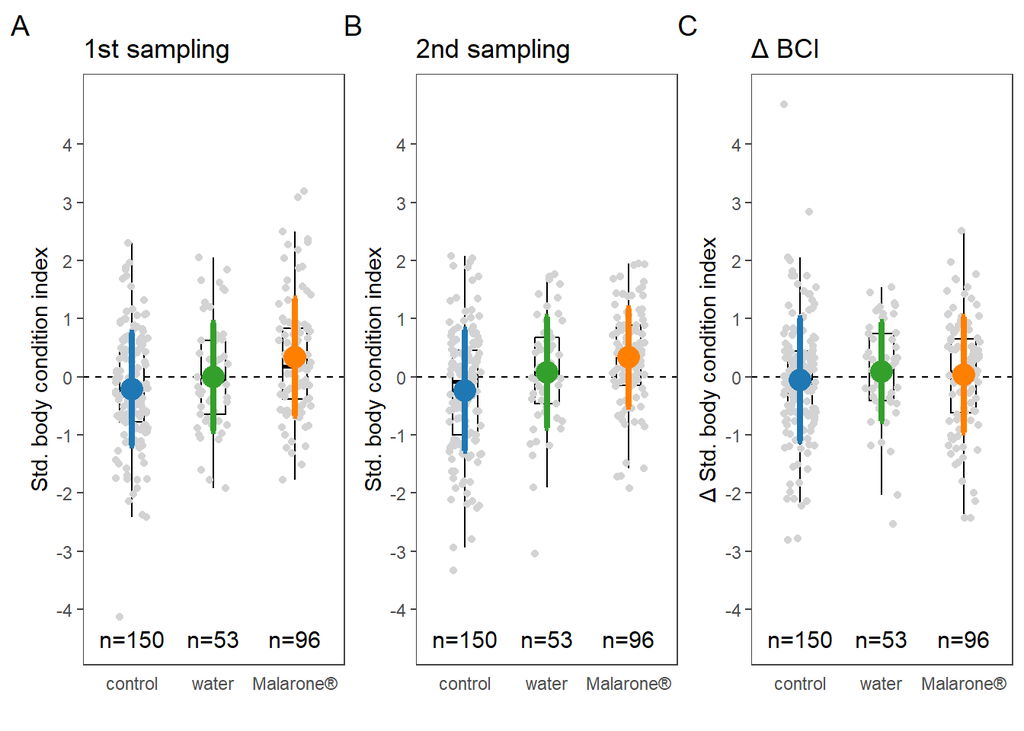

```r
g1_t1 <- ggplot(malarone.data) +
  aes(Treatment, body_condition.1) +
  geom_hline(yintercept = mean(malarone.data$body_condition.1, na.rm = T), linetype = "dashed") +
  geom_boxplot(color = "black", outlier.shape = NA, size = .5, width = .3, na.rm = T) +
  geom_jitter(color = 'lightgrey', width = 0.2, height = 0, na.rm = T) +
  stat_n_text(na.rm = T, y.pos = -Inf, vjust = -1) +
  labs(x = "", y = "Std. body condition index") +
  stat_summary(fun = mean, colour = c("#1F78B4", "#33A02C", "#FF7F00"), geom = "errorbar",
               size = 1.5 , width = 0.05, show.legend = FALSE,
               fun.max = function(x) mean(x) + sd(x),
               fun.min = function(x) mean(x) - sd(x), na.rm = T) +
  stat_summary(fun = mean, colour = c("#1F78B4", "#33A02C", "#FF7F00"), geom = "point",
               size = 5 ,show.legend = FALSE, na.rm = T) +
  theme_article() +
  theme(legend.position = "none",
        axis.line.x = element_blank(),
        axis.ticks.x = element_blank(),
        plot.margin = margin(0, 0, 0, 0, "cm")) +
  scale_y_continuous(limits = c(-4.5, 4.75), breaks = seq(-4, 4, 1)) +
  ggtitle("1st sampling")


g1_t2 <- ggplot(malarone.data) +
  aes(Treatment, body_condition.2) +
  geom_hline(yintercept = mean(malarone.data$body_condition.2, na.rm = T), linetype = "dashed") +
  geom_boxplot(color = "black", outlier.shape = NA, size = .5, width = .3, na.rm = T) +
  geom_jitter(color = 'lightgrey', width = 0.2, height = 0, na.rm = T) +
  stat_n_text(na.rm = T, y.pos = -Inf, vjust = -1) +
  labs(x = "", y = "Std. body condition index") +
  stat_summary(fun = mean, colour = c("#1F78B4", "#33A02C", "#FF7F00"), geom = "errorbar",
               size = 1.5 , width = 0.05, show.legend = FALSE,
               fun.max = function(x) mean(x) + sd(x),
               fun.min = function(x) mean(x) - sd(x), na.rm = T) +
  stat_summary(fun = mean, colour = c("#1F78B4", "#33A02C", "#FF7F00"), geom = "point",
               size = 5 ,show.legend = FALSE, na.rm = T) +
  theme_article() +
  theme(legend.position = "none",
        axis.line.x = element_blank(),
        axis.ticks.x = element_blank(),
        plot.margin = margin(0, 0, 0, 0, "cm")) +
  scale_y_continuous(limits = c(-4.5, 4.75), breaks = seq(-4, 4, 1)) +
  ggtitle("2nd sampling")

g1_delta <- ggplot(malarone.data) +
  aes(Treatment,delta_body_condition) +
  geom_hline(yintercept = mean(malarone.data$delta_body_condition, na.rm = T), linetype = "dashed") +
  geom_boxplot(color = "black", outlier.shape = NA, size = .5, width = .3, na.rm = T) +
  geom_jitter(color = 'lightgrey', width = 0.2, height = 0, na.rm = T) +
  stat_n_text(na.rm = T, y.pos = -Inf, vjust = -1) +
  labs(x = "", y = "\U0394 Std. body condition index") +
  stat_summary(fun = mean, colour = c("#1F78B4", "#33A02C", "#FF7F00"), geom = "errorbar",
               size = 1.5 , width = 0.05, show.legend = FALSE,
               fun.max = function(x) mean(x) + sd(x),
               fun.min = function(x) mean(x) - sd(x), na.rm = T) +
  stat_summary(fun = mean, colour = c("#1F78B4", "#33A02C", "#FF7F00"), geom = "point",
               size = 5 ,show.legend = FALSE, na.rm = T) +
  theme_article() +
  theme(legend.position = "none",
        axis.line.x = element_blank(),
        axis.ticks.x = element_blank(),
        plot.margin = margin(0, 0, 0, 0, "cm")) +
  scale_y_continuous(limits = c(-4.5, 4.75), breaks = seq(-4, 4, 1)) +
  ggtitle("\U0394 BCI")

g1_t1 + g1_t2 + g1_delta + plot_annotation(tag_levels = 'A') &
  theme(plot.tag = element_text(size = 14))
```

As shown above, there was some heterogeneity among treatment in the mean body condition index before treatment. Therefore, we used the change in body condition ($\Delta (2nd~sample - 1st~sample$)

```r
## Run LMM
## -----------------------------------------------------------------------------
model.bci <- lmerTest::lmer(delta_body_condition ~ Treatment + avg_age + days_resample + Year + (1|Nest),
                            data = malarone.data)

## Summarise model
## -----------------------------------------------------------------------------
summary.model <- summary(model.bci)[["coefficients"]]
pander::pandoc.table(summary.model)
```

```
##
## -------------------------------------------------------------------------------
##          &nbsp;           Estimate    Std. Error    df     t value    Pr(>|t|)
## ------------------------ ----------- ------------ ------- ---------- ----------
##     **(Intercept)**        0.3986       0.4107     226.6    0.9706     0.3328
##
##    **Treatmentwater**     -0.004333     0.1772     285.3   -0.02445    0.9805
##
##  **TreatmentMalarone®**    0.08625      0.1603     240.1    0.5382     0.591
##
##       **avg_age**         -0.01761     0.01434      240     -1.228     0.2207
##
##    **days_resample**       0.03858     0.02128     287.9    1.813     0.07091
##
##       **Year2016**         -0.9703      0.5786     55.25    -1.677     0.0992
##
##       **Year2018**         -0.3928      0.1824     164.6    -2.153    0.03275
##
##       **Year2019**         -0.5215      0.1952     133.8    -2.671     0.0085
## -------------------------------------------------------------------------------
```

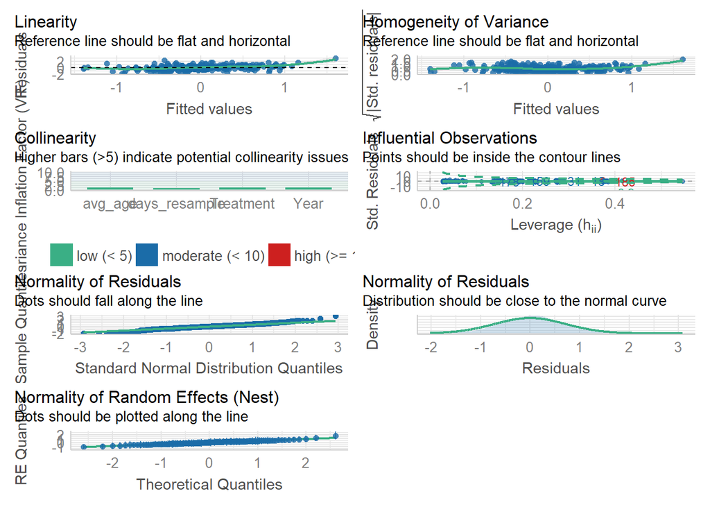

```r
## Check model assumptions
## -----------------------------------------------------------------------------
performance::check_model(model.bci)
```

```r
performance::model_performance(model.bci)
```

```
## # Indices of model performance
##
## AIC     |     BIC | R2 (cond.) | R2 (marg.) |   ICC |  RMSE | Sigma
## -------------------------------------------------------------------
## 855.391 | 892.396 |      0.406 |      0.075 | 0.358 | 0.725 | 0.819
```

```r
## Predicted values for each treatment
## -----------------------------------------------------------------------------
pred.bci <- get_model_data(model.bci, type = 'pred', terms = "Treatment") %>%
  mutate(x = factor(x = c("control","water","Malarone®"), levels = c("control","water","Malarone®")))

## add sample size to labels
## -----------------------------------------------------------------------------
n <- table(malarone.data$Treatment[!is.na(malarone.data$delta_body_condition)])
pred.bci <- pred.bci %>%
  mutate(x = paste0(x,"\nn=",n))

## Plot:
## 1.) predictions and corresponding error margins
## 2.) indicate significant differences based on tukey contrasts
## 3.) Jitter not fitting as corrected for considerable among-year variation
## -----------------------------------------------------------------------------
g1_pred_delta <- ggplot(pred.bci, aes(x = x, y = predicted, color=x, fill=x)) +
  # geom_hline(yintercept = mean(pred.bci$predicted, na.rm = T), linetype = "dashed") +
  labs(x = "Treatment", y = "\U0394 body condition\n(z-transformed)") +
  scale_fill_manual(values=c("#1F78B4",  "#FF7F00", "#33A02C"), labels = c("control","Malarone®","water")) +
  guides(fill = guide_legend(override.aes=list(shape = 22, size=6))) +
  geom_errorbar(aes(ymin = conf.low, ymax = conf.high), colour = 'black', size = 1.5, width = .1) +
  geom_errorbar(aes(ymin = predicted - std.error, ymax = predicted + std.error) ,
                size = 8, colour = c("#1F78B4", "#33A02C", "#FF7F00"), width = 0) +
  geom_point(color = "black", size = 2) +
  scale_y_continuous(breaks = seq(0, 0.6, 0.1), limits = c(-0.06, 0.64)) +
  theme_article(base_size = 12) +
  theme(axis.text.x = element_blank(),
        legend.title = element_blank(),
        axis.title = element_text(size=10),
        axis.line.x = element_blank(),
        axis.ticks.x = element_blank(),
        plot.margin = margin(0, 0, 0, 0, "cm"))
```

#### Growth rate between control and Malarone® treated nestlings

Visualising the raw data

```r
g2_water <- ggplot(malarone.data, aes(Treatment, growth_rate)) +
  geom_hline(yintercept = mean(malarone.data$growth_rate, na.rm = T), linetype = "dashed") +
  geom_boxplot(color = "black", outlier.shape = NA, size = .5, width = .3, na.rm = T) +
  geom_jitter(color = 'lightgrey', width = 0.2, height = 0, na.rm = T) +
  stat_n_text(na.rm = T, y.pos = -Inf, vjust = -1) +
  labs(x = "", y = "Std. growth rate") +
  stat_summary(fun = mean, colour = c("#1F78B4", "#33A02C", "#FF7F00"), geom = "errorbar",
               size = 1.5 , width = 0.05, show.legend = FALSE,
               fun.max = function(x) mean(x) + sd(x),
               fun.min = function(x) mean(x) - sd(x), na.rm = T) +
  stat_summary(fun = mean, colour = c("#1F78B4", "#33A02C", "#FF7F00"), geom = "point",
               size = 5 ,show.legend = FALSE, na.rm = T) +
  theme_article() +
  theme(legend.position = "none",
        axis.line.x = element_blank(),
        axis.ticks.x = element_blank(),
        plot.margin = margin(0, 0, 0, 0, "cm"))
```

Modelling treatment effects while controlling for age and year-specific variation

```r
## Here, scaling is IMPORTANT
lmer_gr_treat <- lmerTest::lmer(growth_rate ~ Treatment + avg_age + days_resample + Sex + Year + (1|Nest),
                                data = malarone.data)

## Summarise model
## -----------------------------------------------------------------------------
summary.model <- summary(lmer_gr_treat)[["coefficients"]]
pander::pandoc.table(summary.model)
```

```
##
## ------------------------------------------------------------------------------
##          &nbsp;           Estimate   Std. Error    df     t value   Pr(>|t|)
## ------------------------ ---------- ------------ ------- --------- -----------
##     **(Intercept)**        2.601       0.354      215.3    7.347    4.141e-12
##
##    **Treatmentwater**     -0.06671     0.153      281.1   -0.4361    0.6631
##
##  **TreatmentMalarone®**   0.03461      0.1378     225.9   0.2512     0.8019
##
##       **avg_age**         -0.09398     0.0123     231.8   -7.641    5.671e-13
##
##    **days_resample**      0.009314    0.01859     289.6    0.501     0.6167
##
##       **SexMale**         -0.3712     0.09404     265.4   -3.947    0.0001014
##
##       **Year2016**        -0.6632      0.4723     48.87   -1.404     0.1666
##
##       **Year2018**        -0.2811      0.1542     161.7   -1.823     0.07017
##
##       **Year2019**        -0.4703      0.1642     130.4   -2.864     0.00487
## ------------------------------------------------------------------------------
```

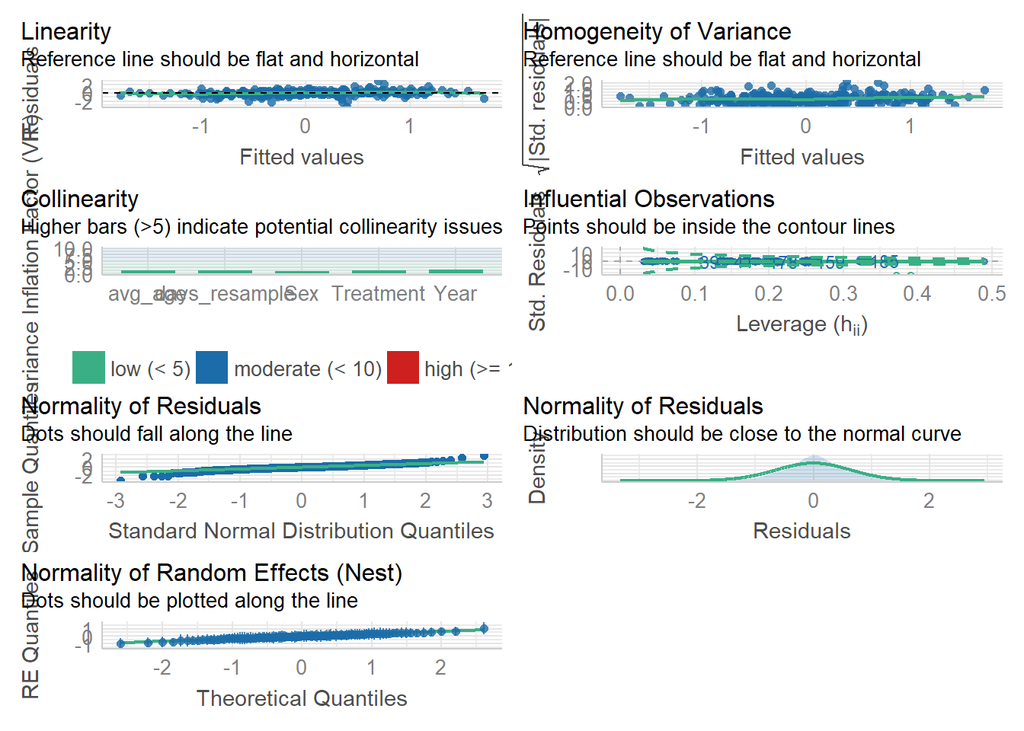

```r
## Check model assumptions: okayish
## -----------------------------------------------------------------------------
performance::check_model(lmer_gr_treat)
```

```r
performance::model_performance(lmer_gr_treat)
```

```
## # Indices of model performance
##
## AIC     |     BIC | R2 (cond.) | R2 (marg.) |   ICC |  RMSE | Sigma
## -------------------------------------------------------------------
## 776.152 | 816.856 |      0.512 |      0.298 | 0.305 | 0.650 | 0.726
```

```r
## Predicted values for each treatment
## -----------------------------------------------------------------------------
mod_gr <- get_model_data(lmer_gr_treat,type='pred',terms="Treatment") %>%
  mutate(x = factor(c("control","water","Malarone®"), levels = c("control","water","Malarone®")))

## add sample size to labels
## -----------------------------------------------------------------------------
n <- table(malarone.data$Treatment[!is.na(malarone.data$growth_rate)])
mod_gr <- mod_gr %>%
  mutate(x = paste0(x,"\nn=",n))

g2_pred <- ggplot(mod_gr, aes(x = x, y = predicted)) +
  # geom_hline(yintercept = mean(mod_gr$predicted, na.rm = T), linetype = "dashed") +
  labs(x = "Treatment", y = "growth rate [g/day]\n(z-transformed)") +
  geom_errorbar(aes(ymin = conf.low, ymax = conf.high), colour = 'black', size = 1.5, width = .1) +
  geom_errorbar(aes(ymin = predicted - std.error , ymax = predicted + std.error),
                size = 8, colour = c("#1F78B4", "#33A02C", "#FF7F00"), width = 0) +
  geom_point(color = "black", size = 2) +
  theme_article(base_size = 12) +
  theme(axis.text.x = element_blank(),
        axis.title=element_text(size= 10),
        legend.position = "none",
        axis.line.x = element_blank(),
        axis.ticks.x = element_blank(),
        plot.margin = margin(0, 0, 0, 0, "cm"))
scale_y_continuous(breaks = seq(0, 0.6, 0.1), limits = c(-0.06, 0.64))
```

```
## <ScaleContinuousPosition>
##  Range:
##  Limits: -0.06 -- 0.64
```

### `Bloodchemistry`

#### Comparing parameter distributions among groups

First, visualising raw data

```r
## A: Age
## -----------------------------------------------------------------------------
means <- bloodchem.data %>%
  group_by(Treatment) %>%
  summarise(MEAN = mean(Age),
            SD = sd(Age),
            LCL = quantile(Age, 0.025),
            UCL = quantile(Age, 0.975))
A <-
  ggplot(means, aes(x = Treatment, y = MEAN)) +
  theme_article(base_size = 8) +
  theme(
    aspect.ratio = 1,
    legend.position = "none",
    axis.text.x = element_blank(),
    axis.ticks.x = element_blank(),
    axis.title.x = element_blank()) +
  scale_color_manual(values = c("#A6CEE3", "#1F78B4", "#FDBF6F", "#FF7F00")) +
  geom_errorbar(aes(ymin = LCL, ymax = UCL),
                width = 0.1, size = 1) +
  geom_errorbar(aes(col = Treatment, ymin = MEAN - SD, ymax = MEAN + SD),
                width = 0, size = 8) +
  geom_point(size = 2) +
  geom_jitter(data = bloodchem.data, aes(y = Age),
              height = 0, size = 0.8, alpha = .6, width = .2, shape = 1) +
  # geom_line(data = bloodchem.data,
  #           aes(y = Age, group = Ring), col = "Black", lty = "dotted") +
  labs(tag = "A") +
  scale_y_continuous(breaks = seq(15, 40, 5)) +
  ylab("Nestling age\n(days)")

## B: Body condition index
## -----------------------------------------------------------------------------
means <- bloodchem.data %>%
  group_by(Treatment) %>%
  summarise(MEAN = mean(BCI),
            SD = sd(BCI),
            LCL = quantile(BCI, 0.025),
            UCL = quantile(BCI, 0.975))
B <-
  ggplot(means, aes(x = Treatment, y = MEAN)) +
  theme_article(base_size = 8) +
  theme(
    aspect.ratio = 1,
    legend.position = "none",
    axis.text.x = element_blank(),
    axis.ticks.x = element_blank(),
    axis.title.x = element_blank()) +
  scale_color_manual(values = c("#A6CEE3", "#1F78B4", "#FDBF6F", "#FF7F00")) +
  geom_errorbar(aes(ymin = LCL, ymax = UCL),
                width = 0.1, size = 1) +
  geom_errorbar(aes(col = Treatment, ymin = MEAN - SD, ymax = MEAN + SD),
                width = 0, size = 8) +
  geom_point(size = 2) +
  geom_jitter(data = bloodchem.data, aes(y = BCI), height = 0, size = 0.8, alpha = .6, width = .2, shape = 1) +
  # geom_line(data = bloodchem.data, aes(y = BCI, group = Ring), col = "Black", lty = "dotted") +
  labs(tag = "B", subtitle = "ns") +
  scale_y_continuous(breaks = seq(-100, 200, 50)) +
  ylab("Body condition index\n")

## C: Leucocytozoon
## -----------------------------------------------------------------------------
# means <- bloodchem.data %>%
#   group_by(Treatment) %>%
#   summarise(MEAN = mean(Leucocytozoon),
#             SD = sd(Leucocytozoon),
#             LCL = quantile(Leucocytozoon, 0.025),
#             UCL = quantile(Leucocytozoon, 0.975))
# C <-
#   ggplot(means, aes(x = Treatment, y = MEAN)) +
#   theme_article(base_size = 10) +
#   theme(
#     legend.position = "none",
#     axis.text.x = element_blank(),
#     axis.ticks.x = element_blank(),
#     axis.title.x = element_blank()) +
#   scale_color_manual(values = c("#A6CEE3", "#1F78B4", "#FDBF6F", "#FF7F00")) +
#   geom_errorbar(aes(ymin = LCL, ymax = UCL),
#                 width = 0.1, size = 1) +
#   geom_errorbar(aes(col = Treatment, ymin = MEAN - SD, ymax = MEAN + SD),
#                 width = 0, size = 8) +
#   geom_point(size = 2) +
#   geom_jitter(data = bloodchem.data, aes(y = Leucocytozoon), height = 0, size = 0.8, alpha = .6, width = .2, shape = 1) +
#   geom_line(data = bloodchem.data, aes(y = Leucocytozoon, group = Ring), col = "Black", lty = "dotted") +
#   labs(tag = "C") +
#   scale_y_continuous(breaks = seq(0, 4, 1)) +
#   ylab("Leucocytozoon\ninfection intensity")

## D: AP
## -----------------------------------------------------------------------------
means <- bloodchem.data %>%
  group_by(Treatment) %>%
  summarise(MEAN = mean(AP),
            SD = sd(AP),
            LCL = quantile(AP, 0.025),
            UCL = quantile(AP, 0.975))
C <-
  ggplot(means, aes(x = Treatment, y = MEAN)) +
  theme_article(base_size = 8) +
  theme(
    aspect.ratio = 1,
    legend.position = "none",
    axis.text.x = element_blank(),
    axis.ticks.x = element_blank(),
    axis.title.x = element_blank()) +
  scale_color_manual(values = c("#A6CEE3", "#1F78B4", "#FDBF6F", "#FF7F00")) +
  geom_errorbar(aes(ymin = LCL, ymax = UCL),
                width = 0.1, size = 1) +
  geom_errorbar(aes(col = Treatment, ymin = MEAN - SD, ymax = MEAN + SD),
                width = 0, size = 8) +
  geom_point(size = 2) +
  geom_jitter(data = bloodchem.data, aes(y = AP), height = 0, size = 0.8, alpha = .6, width = .2, shape = 1) +
  # geom_line(data = bloodchem.data, aes(y = AP, group = Ring), col = "Black", lty = "dotted") +
  labs(tag = "C", subtitle = "ns") +
  ylab("AP\n(U/I)")

## D: AST
## -----------------------------------------------------------------------------
means <- bloodchem.data %>%
  group_by(Treatment) %>%
  summarise(MEAN = mean(AST),
            SD = sd(AST),
            LCL = quantile(AST, 0.025),
            UCL = quantile(AST, 0.975))
D <-
  ggplot(means, aes(x = Treatment, y = MEAN)) +
  theme_article(base_size = 8) +
  theme(
    aspect.ratio = 1,
    legend.position = "none",
    axis.text.x = element_blank(),
    axis.ticks.x = element_blank(),
    axis.title.x = element_blank()) +
  scale_color_manual(values = c("#A6CEE3", "#1F78B4", "#FDBF6F", "#FF7F00")) +
  geom_errorbar(aes(ymin = LCL, ymax = UCL),
                width = 0.1, size = 1) +
  geom_errorbar(aes(col = Treatment, ymin = MEAN - SD, ymax = MEAN + SD),
                width = 0, size = 8) +
  geom_point(size = 2) +
  geom_jitter(data = bloodchem.data, aes(y = AST), height = 0, size = 0.8, alpha = .6, width = .2, shape = 1) +
  # geom_line(data = bloodchem.data, aes(y = AST, group = Ring), col = "Black", lty = "dotted") +
  labs(tag = "D", subtitle = "ns") +
  ylab("AST\n(U/I)")


## E: GGT
## -----------------------------------------------------------------------------
means <- bloodchem.data %>%
  group_by(Treatment) %>%
  summarise(MEAN = mean(GGT),
            SD = sd(GGT),
            LCL = quantile(GGT, 0.025),
            UCL = quantile(GGT, 0.975))
E <-
  ggplot(means, aes(x = Treatment, y = MEAN)) +
  theme_article(base_size = 8) +
  theme(
    aspect.ratio = 1,
    legend.position = "none",
    axis.text.x = element_blank(),
    axis.ticks.x = element_blank(),
    axis.title.x = element_blank()) +
  scale_color_manual(values = c("#A6CEE3", "#1F78B4", "#FDBF6F", "#FF7F00")) +
  geom_errorbar(aes(ymin = LCL, ymax = UCL),
                width = 0.1, size = 1) +
  geom_errorbar(aes(col = Treatment, ymin = MEAN - SD, ymax = MEAN + SD),
                width = 0, size = 8) +
  geom_point(size = 2) +
  geom_jitter(data = bloodchem.data, aes(y = GGT), height = 0, size = 0.8, alpha = .6, width = .2, shape = 1) +
  # geom_line(data = bloodchem.data, aes(y = GGT, group = Ring), col = "Black", lty = "dotted") +
  labs(tag = "E", subtitle = "ns") +
  ylab("GGT\n(U/I)")
```

```r
## F: BuChE
## -----------------------------------------------------------------------------
means <- bloodchem.data %>%
  group_by(Treatment) %>%
  summarise(MEAN = mean(BuChE),
            SD = sd(BuChE),
            LCL = quantile(BuChE, 0.025),
            UCL = quantile(BuChE, 0.975))
F <-
  ggplot(means, aes(x = Treatment, y = MEAN)) +
  theme_article(base_size = 8) +
  theme(
    aspect.ratio = 1,
    legend.position = "none",
    axis.text.x = element_blank(),
    axis.ticks.x = element_blank(),
    axis.title.x = element_blank()) +
  scale_color_manual(values = c("#A6CEE3", "#1F78B4", "#FDBF6F", "#FF7F00")) +
  geom_errorbar(aes(ymin = LCL, ymax = UCL),
                width = 0.1, size = 1) +
  geom_errorbar(aes(col = Treatment, ymin = MEAN - SD, ymax = MEAN + SD),
                width = 0, size = 8) +
  geom_point(size = 2) +
  geom_jitter(data = bloodchem.data, aes(y = BuChE), height = 0, size = 0.8, alpha = .6, width = .2, shape = 1) +
  # geom_line(data = bloodchem.data, aes(y = BuChE, group = Ring), col = "Black", lty = "dotted") +
  labs(tag = "F", subtitle = "ns") +
  ylab("BuChE\n(KU/I)")

## G: BA
## -----------------------------------------------------------------------------
means <- bloodchem.data %>%
  group_by(Treatment) %>%
  summarise(MEAN = mean(BA),
            SD = sd(BA),
            LCL = quantile(BA, 0.025),
            UCL = quantile(BA, 0.975))
G <-
  ggplot(means, aes(x = Treatment, y = MEAN)) +
  theme_article(base_size = 8) +
  theme(
    aspect.ratio = 1,
    legend.position = "none",
    axis.text.x = element_blank(),
    axis.ticks.x = element_blank(),
    axis.title.x = element_blank(),
    plot.margin = unit(c(0,-0.2,0,0),"cm")) +
  scale_color_manual(values = c("#A6CEE3", "#1F78B4", "#FDBF6F", "#FF7F00")) +
  geom_errorbar(aes(ymin = LCL, ymax = UCL),
                width = 0.1, size = 1) +
  geom_errorbar(aes(col = Treatment, ymin = MEAN - SD, ymax = MEAN + SD),
                width = 0, size = 8) +
  geom_point(size = 2) +
  geom_jitter(data = bloodchem.data, aes(y = BA), height = 0, size = 0.8, alpha = .6, width = .2, shape = 1) +
  # geom_line(data = bloodchem.data, aes(y = BA, group = Ring), col = "Black", lty = "dotted") +
  labs(tag = "G", subtitle = "ns") +
  ylab("BA\n(µmol/L)")

## H: LDH
## -----------------------------------------------------------------------------
means <- bloodchem.data %>%
  group_by(Treatment) %>%
  summarise(MEAN = mean(LDH),
            SD = sd(LDH),
            LCL = quantile(LDH, 0.025),
            UCL = quantile(LDH, 0.975))
H <-
  ggplot(means, aes(x = Treatment, y = MEAN)) +
  theme_article(base_size = 8) +
  theme(
    aspect.ratio = 1,
    legend.position = "none",
    axis.text.x = element_blank(),
    axis.ticks.x = element_blank(),
    axis.title.x = element_blank(),
    plot.margin = unit(c(0,-0.2,0,0),"cm")) +
  scale_color_manual(values = c("#A6CEE3", "#1F78B4", "#FDBF6F", "#FF7F00")) +
  geom_errorbar(aes(ymin = LCL, ymax = UCL),
                width = 0.1, size = 1) +
  geom_errorbar(aes(col = Treatment, ymin = MEAN - SD, ymax = MEAN + SD),
                width = 0, size = 8) +
  geom_point(size = 2) +
  geom_jitter(data = bloodchem.data, aes(y = LDH), height = 0, size = 0.8, alpha = .6, width = .2, shape = 1) +
  # geom_line(data = bloodchem.data, aes(y = LDH, group = Ring), col = "Black", lty = "dotted") +
  labs(tag = "H", subtitle = "ns") +
  scale_x_discrete(guide = guide_axis(n.dodge = 2)) +
  ylab("LDH\n(U/I)")

## I: CK
## -----------------------------------------------------------------------------
means <- bloodchem.data %>%
  group_by(Treatment) %>%
  summarise(MEAN = mean(CK),
            SD = sd(CK),
            LCL = quantile(CK, 0.025),
            UCL = quantile(CK, 0.975))
I <-
  ggplot(means, aes(x = Treatment, y = MEAN)) +
  theme_article(base_size = 8) +
  theme(
    aspect.ratio = 1,
    legend.position = "none",
    axis.title.x = element_blank(),
    axis.text.x = element_blank(),
    axis.ticks.x = element_blank(),
    #axis.text.x = element_text(angle=45, vjust=0.65, hjust=0.9)
  ) +
  scale_color_manual(values = c("#A6CEE3", "#1F78B4", "#FDBF6F", "#FF7F00")) +
  geom_errorbar(aes(ymin = LCL, ymax = UCL),
                width = 0.1, size = 1) +
  geom_errorbar(aes(col = Treatment, ymin = MEAN - SD, ymax = MEAN + SD),
                width = 0, size = 8) +
  geom_point(size = 2) +
  geom_jitter(data = bloodchem.data, aes(y = CK), height = 0, size = 0.8, alpha = .6, width = .2, shape = 1) +
  # geom_line(data = bloodchem.data, aes(y = CK, group = Ring), col = "Black", lty = "dotted") +
  labs(tag = "I", subtitle = "ns") +
  # scale_x_discrete(guide = guide_axis(n.dodge = 2)) +
  ylab("CK\n(U/I)")

## J: ALB
## -----------------------------------------------------------------------------
means <- bloodchem.data %>%
  group_by(Treatment) %>%
  summarise(MEAN = mean(ALB),
            SD = sd(ALB),
            LCL = quantile(ALB, 0.025),
            UCL = quantile(ALB, 0.975))
J <-
  ggplot(means, aes(x = Treatment, y = MEAN)) +
  theme_article(base_size = 8) +
  theme(
    aspect.ratio = 1,
    legend.position = "none",
    axis.title.x = element_blank(),
    axis.text.x = element_blank(),
    axis.ticks.x = element_blank(),
    #    axis.text.x = element_text(angle=45, vjust=0.65, hjust=0.9)
  ) +
  scale_color_manual(values = c("#A6CEE3", "#1F78B4", "#FDBF6F", "#FF7F00")) +
  geom_errorbar(aes(ymin = LCL, ymax = UCL),
                width = 0.1, size = 1) +
  geom_errorbar(aes(col = Treatment, ymin = MEAN - SD, ymax = MEAN + SD),
                width = 0, size = 8) +
  geom_point(size = 2) +
  geom_jitter(data = bloodchem.data, aes(y = ALB), height = 0, size = 0.8, alpha = .6, width = .2, shape = 1) +
  # geom_line(data = bloodchem.data, aes(y = ALB, group = Ring), col = "Black", lty = "dotted") +
  labs(tag = "J", subtitle = "ns") +
  # scale_x_discrete(guide = guide_axis(n.dodge = 2)) +
  ylab("ALB\n(g/L)")

## K: TP
## -----------------------------------------------------------------------------
means <- bloodchem.data %>%
  group_by(Treatment) %>%
  summarise(MEAN = mean(TP),
            SD = sd(TP),
            LCL = quantile(TP, 0.025),
            UCL = quantile(TP, 0.975))
```

```r
K <-
  ggplot(means, aes(x = Treatment, y = MEAN)) +
  theme_article(base_size = 8) +
  theme(
    aspect.ratio = 1,
    legend.position = c(2,0.5),
    legend.title = element_text(size=8),
    legend.text = element_text(size=8),
    legend.key.height = unit(0.05, 'cm'),
    legend.key.width = unit(0.05, 'cm'),
    axis.title.x = element_blank(),
    axis.text.x = element_blank(),
    axis.ticks.x = element_blank(),
    #axis.text.x = element_text(angle=45, vjust=0.65, hjust=0.9)
    ) +
  scale_color_manual(values = c("#A6CEE3", "#1F78B4", "#FDBF6F", "#FF7F00")) +
  geom_errorbar(aes(ymin = LCL, ymax = UCL),
                width = 0.1, size = 1) +
  geom_errorbar(aes(col = Treatment, ymin = MEAN - SD, ymax = MEAN + SD),
                width = 0, size = 8) +
  geom_point(size = 2) +
  geom_jitter(data = bloodchem.data, aes(y = TP), height = 0, size = 0.8, alpha = .6, width = .2, shape = 1) +
  # geom_line(data = bloodchem.data, aes(y = TP, group = Ring), col = "Black", lty = "dotted") +
  labs(tag = "K", subtitle = "ns") +
  guides(color=guide_legend(ncol=2))+
  # scale_x_discrete(guide = guide_axis(n.dodge = 2)) +
  ylab("TP\n(g/L)")
```

#### Testing for among group differences

Data are not normally distributed, and thus all group comparisons are performed using non-parametric tests, i.e., Wilcoxon signed rank test for paired data and Mann-Whitney test for unpaired data.

The following function is defined to estimate these statistics for all parameters:

```r
## function to compute paired and unpaired tests
## -----------------------------------------------------------------------------
u_test <- function(var = NULL, x_name = "Post-Mal", y_name = "Post-Control",
                   paired = FALSE) {

  ## Get data of groups to compare
  ## ---------------------------------------------------------------------------
  x <- bloodchem.data[[var]][bloodchem.data$Treatment == x_name]
  y <- bloodchem.data[[var]][bloodchem.data$Treatment == y_name]

  ## Run test and retrun results
  ## ---------------------------------------------------------------------------
  u <- wilcox.test(x, y, paired = paired)

  return(data.frame(parameter = var,
                    group_x = x_name,
                    group_y = y_name,
                    U_value = u$statistic,
                    p_value = u$p.value))
}
```

Apply the function to all comparisons of interest

```r
## Unpaired tests
## -----------------------------------------------------------------------------
u_tests <- rbind(
  ## 1.) Pre-Control vs Pre-Mal, unpaired
  lapply(names(bloodchem.data)[c(4:7, 9:13)], u_test,
         x_name = "Pre-Control", y_name = "Pre-Mal") %>%
    do.call("rbind",.) %>%
    mutate(p_value_adj = p.adjust(p_value, method = "BH")),
  ## 2.) Post-Control vs Post-Mal, unpaired
  lapply(names(bloodchem.data)[c(4:7, 9:13)], u_test,
         x_name = "Post-Control", y_name = "Post-Mal") %>%
    do.call("rbind",.) %>%
    mutate(p_value_adj = p.adjust(p_value, method = "BH"))
)
write.csv(u_tests, file = "data/u_tests.csv")
knitr::knit_print(u_tests)
```

```
##     parameter      group_x  group_y U_value    p_value p_value_adj
## W          AP  Pre-Control  Pre-Mal   195.0 0.74626084   0.8395434
## W1        AST  Pre-Control  Pre-Mal   206.5 0.96177243   0.9617724
## W2        GGT  Pre-Control  Pre-Mal   257.0 0.23845854   0.5365317
## W3      BuChE  Pre-Control  Pre-Mal   274.0 0.12191333   0.5365317
## W4         BA  Pre-Control  Pre-Mal   242.0 0.44157232   0.6647539
## W5        LDH  Pre-Control  Pre-Mal   224.0 0.72825072   0.8395434
## W6         CK  Pre-Control  Pre-Mal   241.5 0.44316928   0.6647539
## W7        ALB  Pre-Control  Pre-Mal   157.0 0.21687592   0.5365317
## W8         TP  Pre-Control  Pre-Mal   151.0 0.16533491   0.5365317
## W9         AP Post-Control Post-Mal    67.5 0.66924492   0.8354203
## W11       AST Post-Control Post-Mal    55.0 0.74259580   0.8354203
## W21       GGT Post-Control Post-Mal    68.0 0.63616495   0.8354203
## W31     BuChE Post-Control Post-Mal    81.5 0.17592396   0.5277719
## W41        BA Post-Control Post-Mal    87.0 0.08794611   0.3957575
## W51       LDH Post-Control Post-Mal    75.5 0.34075185   0.7666917
## W61        CK Post-Control Post-Mal    73.0 0.43846324   0.7892338
## W71       ALB Post-Control Post-Mal    33.5 0.08140623   0.3957575
## W81        TP Post-Control Post-Mal    63.5 0.86871864   0.8687186
```

```r
## Paired tests
## -----------------------------------------------------------------------------
w_tests <- lapply(names(bloodchem.data)[c(4:7, 9:13)], u_test, paired = T,
                  x_name = "Pre-Mal", y_name = "Post-Mal") %>%
  do.call("rbind",.) %>%
  mutate(p_value_adj = p.adjust(p_value, method = "BH"))
write.csv(w_tests, file = "data/w_tests.csv")
knitr::knit_print(w_tests)
```

```
##    parameter group_x  group_y U_value    p_value p_value_adj
## V         AP Pre-Mal Post-Mal       6 0.03220076  0.09660229
## V1       AST Pre-Mal Post-Mal      45 0.32031250  0.46472168
## V2       GGT Pre-Mal Post-Mal       5 0.01414544  0.06365450
## V3     BuChE Pre-Mal Post-Mal      36 0.83105469  0.83105469
## V4        BA Pre-Mal Post-Mal      48 0.20605469  0.37089844
## V5       LDH Pre-Mal Post-Mal      60 0.01367187  0.06365450
## V6        CK Pre-Mal Post-Mal      12 0.06738281  0.15161133
## V7       ALB Pre-Mal Post-Mal      43 0.41308594  0.46472168
## V8        TP Pre-Mal Post-Mal      19 0.41146219  0.46472168
```

## Summary

### Model table

```r
sjPlot::tab_model(
  model.bci,lmer_gr_treat,
  show.ci50 = T ,
  show.stat = T,
  show.reflvl = T,
  string.stat = "t",
  p.val = "kr",
  dv.labels = c("Std. body condition","Std. growth rate"))
```

|  | Std. body condition |  |  |  | Std. growth rate |  |  |  |
| --- | --- | --- | --- | --- | --- | --- | --- | --- |
| Predictors | Estimates | CI | t | p | Estimates | CI | t | p |
| (Intercept) | 0.40 | -0.42 – 1.21 | 0.96 | 0.336 | 2.60 | 1.90 – 3.30 | 7.29 | **<0.001** |
| avg_age | -0.02 | -0.05 – 0.01 | -1.22 | 0.224 | -0.09 | -0.12 – -0.07 | -7.59 | **<0.001** |
| days_resample | 0.04 | -0.00 – 0.08 | 1.80 | 0.073 | 0.01 | -0.03 – 0.05 | 0.50 | 0.619 |
| control | *Reference* |  |  |  | *Reference* |  |  |  |
| water | -0.00 | -0.36 – 0.35 | -0.02 | 0.981 | -0.07 | -0.37 – 0.24 | -0.43 | 0.665 |
| Malarone® | 0.09 | -0.23 – 0.40 | 0.53 | 0.594 | 0.03 | -0.24 – 0.31 | 0.25 | 0.803 |
| Female | *Reference* |  |  |  | *Reference* |  |  |  |
| Male |  |  |  |  | -0.37 | -0.56 – -0.19 | -3.93 | **<0.001** |
| Year2016 | -0.97 | -2.13 – 0.19 | -1.67 | 0.100 | -0.66 | -1.62 – 0.29 | -1.39 | 0.169 |
| Year2018 | -0.39 | -0.75 – -0.03 | -2.14 | **0.034** | -0.28 | -0.59 – 0.02 | -1.81 | 0.072 |
| Year2019 | -0.52 | -0.91 – -0.13 | -2.66 | **0.009** | -0.47 | -0.80 – -0.14 | -2.85 | **0.005** |
| Random Effects |  |  |  |  |  |  |  |  |
| σ<sup>2</sup> | 0.67 |  |  |  | 0.53 |  |  |  |
| τ<sub>00</sub> | 0.37 <sub>Nest</sub> |  |  |  | 0.23 <sub>Nest</sub> |  |  |  |
| ICC | 0.36 |  |  |  | 0.30 |  |  |  |
| N | 110 <sub>Nest</sub> |  |  |  | 110 <sub>Nest</sub> |  |  |  |
| Observations | 299 |  |  |  | 299 |  |  |  |
| Marginal R<sup>2</sup> / Conditional R<sup>2</sup> | 0.075 / 0.406 |  |  |  | 0.298 / 0.512 |  |  |  |

### Multiplots

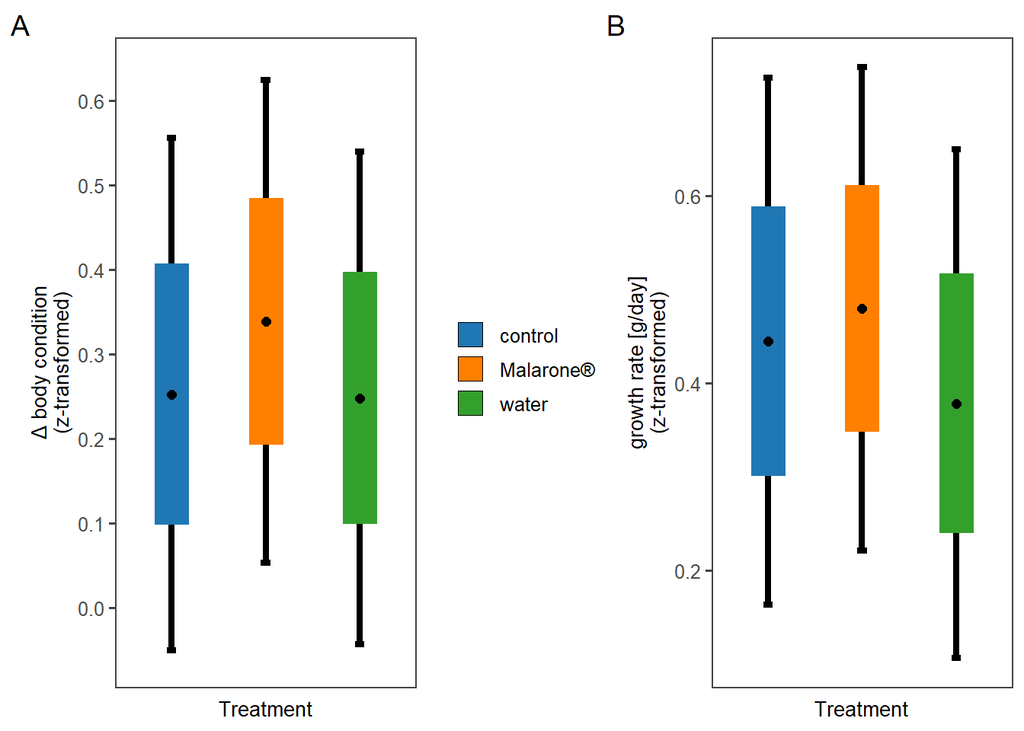

```r
## Malarone® experiment
## -----------------------------------------------------------------------------
g1_pred_delta + g2_pred + plot_annotation(tag_levels = 'A') &
  theme(plot.tag = element_text(size = 14))
```

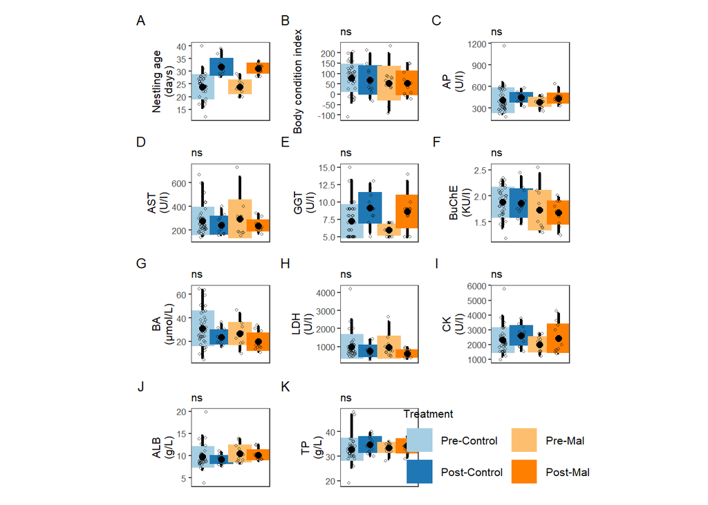

```r
ggsave(filename = "figures/MalaroneMultiplot.png", device = "png", dpi = 300,
       width = 6, height = 4, units = "in")

## Bloodchemistry data
## -----------------------------------------------------------------------------
A + B + C + D + E + F + G + H + I + J + K + plot_spacer() + plot_layout(ncol = 3)
```

```r
ggsave(filename = "figures/BloodChemistryMultiplot.png", device = "png", dpi = 300,
       width = 9, height = 6, units = "in")

## Leveling up graph J + K done with photoshop... - I tried with inset_element() but couldn't get a handle on it
```

### Supplementary analses

Calculating effective Malarone® dose per individual, corrected for body mass:

```r
malarone.data <- malarone.data %>%
  mutate(dose = case_when(Treatment == "Malarone®" ~ 7/Weight.1*100,
                          Treatment == "control" ~ 0,
                          Treatment == "water" ~ 0))
```

Testing for a linear effect of individual-specific Malarone® dose

```r
model.bci.mal <- lmerTest::lmer(delta_body_condition ~ dose + avg_age + days_resample + Year + (1|Nest),
                                data = filter(malarone.data, Treatment == "Malarone®"))

## Summarise model
## -----------------------------------------------------------------------------
summary.model <- summary(model.bci.mal)[["coefficients"]]
pander::pandoc.table(summary.model)
```

```
##
## ------------------------------------------------------------------------
##       &nbsp;         Estimate   Std. Error    df     t value   Pr(>|t|)
## ------------------- ---------- ------------ ------- --------- ----------
##   **(Intercept)**     1.395       1.748      89.49   0.7983     0.4268
##
##      **dose**         0.6049      0.6712     87.93   0.9012     0.3699
##
##     **avg_age**       -0.043     0.04617     89.41   -0.9314    0.3542
##
##  **days_resample**   -0.1097      0.1125     73.17   -0.9754    0.3326
##
##    **Year2018**      -0.5214      0.3359     66.77   -1.552     0.1254
##
##    **Year2019**      -0.3831      0.2326     53.72   -1.647     0.1054
## ------------------------------------------------------------------------
```

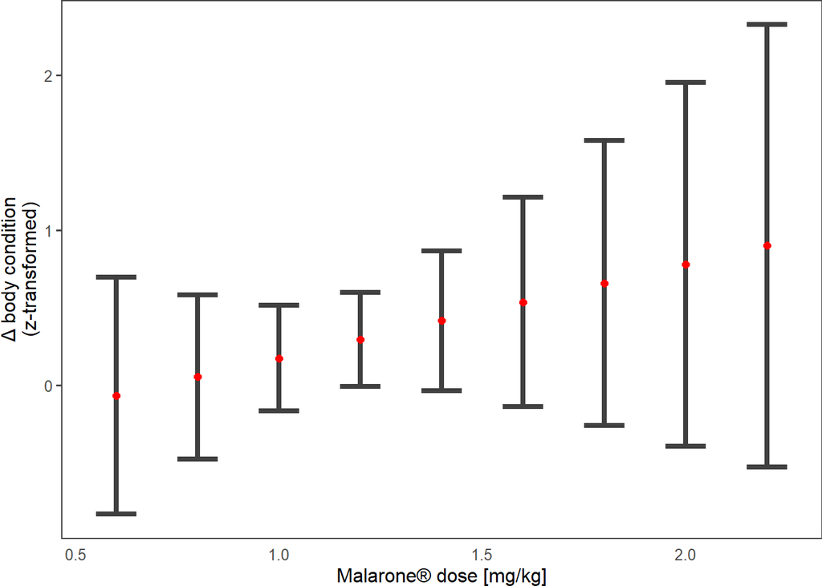

```r
## Predicted values for each treatment
## -----------------------------------------------------------------------------
mod_bci <- get_model_data(model.bci.mal,type='pred',terms="dose")

ggplot(mod_bci, aes(x = x, y = predicted)) +
  labs(x = "Malarone® dose [mg/kg]", y = "\U0394 body condition\n(z-transformed)") +
  geom_errorbar(aes(ymin = conf.low, ymax = conf.high), colour = 'grey25', size = 1.5, width = .1) +
  geom_point(color = "red", size = 2) +
  theme_article(base_size = 12) +
  theme(legend.position = "none",
        axis.line.x = element_blank(),
        axis.ticks.x = element_blank(),
        plot.margin = margin(0, 0, 0, 0, "cm"))
```

```r
ggsave(filename = "figures/BodyCondition_Dose.png", device = "png", dpi = 300,
       width = 6, height = 6, units = "in")
```

```r
lmer_gr_treat.mal <- lmerTest::lmer(growth_rate ~ dose + avg_age + days_resample + Sex + Year + (1|Nest),
                                    data = filter(malarone.data, Treatment == "Malarone®"))

## Summarise model
## -----------------------------------------------------------------------------
summary.model <- summary(lmer_gr_treat.mal)[["coefficients"]]
pander::pandoc.table(summary.model)
```

```
##
## -------------------------------------------------------------------------
##       &nbsp;         Estimate   Std. Error    df     t value   Pr(>|t|)
## ------------------- ---------- ------------ ------- --------- -----------
##   **(Intercept)**     0.5351      1.573      88.81   0.3401     0.7346
##
##      **dose**         1.838       0.6182     87.23    2.973    0.003814
##
##     **avg_age**      -0.04677    0.04299     88.97   -1.088     0.2795
##
##  **days_resample**   -0.1354     0.09219     76.42   -1.469     0.1459
##
##     **SexMale**      -0.7126      0.1684     81.72   -4.232    6.023e-05
##
##    **Year2018**      -0.4952      0.2733     68.58   -1.812     0.07441
##
##    **Year2019**      -0.3943      0.1903     57.89   -2.072     0.04277
## -------------------------------------------------------------------------
```

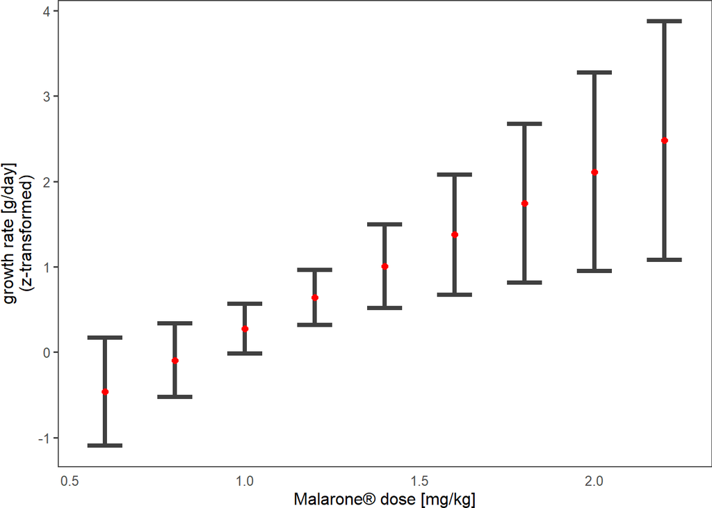

```r
## Predicted values for each treatment
## -----------------------------------------------------------------------------
mod_gr <- get_model_data(lmer_gr_treat.mal,type='pred',terms="dose", )

ggplot(mod_gr, aes(x = x, y = predicted)) +
  labs(x = "Malarone® dose [mg/kg]", y = "growth rate [g/day]\n(z-transformed)") +
  geom_errorbar(aes(ymin = conf.low, ymax = conf.high), colour = 'grey25', size = 1.5, width = .1) +
  geom_point(color = "red", size = 2) +
  theme_article(base_size = 12) +
  theme(legend.position = "none",
        axis.line.x = element_blank(),
        axis.ticks.x = element_blank(),
        plot.margin = margin(0, 0, 0, 0, "cm"))
```

```r
ggsave(filename = "figures/GrowthRate_Dose.png", device = "png", dpi = 300,
       width = 6, height = 6, units = "in")
```

#### Comparing parameters at post-treatment across control, low and high dosage of drug

```r
# three groupings of drug dosage: low, medium and high (under 9.68 mL/Kg, between 9.68 and 12.3 and above 12.3 mL/Kg)

bloodchem.data$dosage_grp=cut(bloodchem.data$Dosage, 3, labels = c('low','medium','high'))

newdata=bloodchem.data[bloodchem.data$Treatment %in% c('Post-Mal','Post-Control'),]
newdata$dosage_grp=as.character(newdata$dosage_grp)
newdata$dosage_grp[is.na(newdata$dosage_grp) == T] <- 'untreated'
newdata$dosage_grp=factor(newdata$dosage_grp, levels=c('low','medium','untreated'), labels=c("Low", "High", "Control"))

## A: AP
## -----------------------------------------------------------------------------

means <- newdata %>%
  group_by(dosage_grp) %>%
  summarise(MEAN = mean(AP),
            SD = sd(AP),
            LCL = quantile(AP, 0.025),
            UCL = quantile(AP, 0.975))

g1=ggplot(means)+aes(x = dosage_grp, y = MEAN)+
  scale_color_manual(values = c("#FDBF6F", "#FF7F00","#1F78B4"))+
  labs(y="AP")+
  geom_errorbar(aes(ymin = LCL, ymax = UCL),
                width = 0.1, size = 1) +
  geom_errorbar(aes(col = dosage_grp, ymin = MEAN - SD, ymax = MEAN + SD),
                width = 0, size = 8) +
  geom_point(size=2)+
  geom_jitter(data = newdata, aes(y = AP), height = 0, size = 2, alpha = .6, width = .2, shape = 1) +
  theme_article(base_size = 8) +
  theme(legend.position = "none",
        axis.title.x = element_blank(), axis.text.x = element_blank())

## B: AST
## -----------------------------------------------------------------------------

means <- newdata %>%
  group_by(dosage_grp) %>%
  summarise(MEAN = mean(AST),
            SD = sd(AST),
            LCL = quantile(AST, 0.025),
            UCL = quantile(AST, 0.975))

g2=ggplot(means)+aes(x = dosage_grp, y = MEAN)+
  scale_color_manual(values = c("#FDBF6F", "#FF7F00","#1F78B4"))+
  labs(y="AST")+
  geom_errorbar(aes(ymin = LCL, ymax = UCL),
                width = 0.1, size = 1) +
  geom_errorbar(aes(col = dosage_grp, ymin = MEAN - SD, ymax = MEAN + SD),
                width = 0, size = 8) +
  geom_point(size=2)+
  geom_jitter(data = newdata, aes(y = AST), height = 0, size = 2, alpha = .6, width = .2, shape = 1) +
  theme_article(base_size = 8) +
  theme(legend.position = "none",
        axis.title.x = element_blank(), axis.text.x = element_blank())

## C: GGT
## -----------------------------------------------------------------------------

means <- newdata %>%
  group_by(dosage_grp) %>%
  summarise(MEAN = mean(GGT),
            SD = sd(GGT),
            LCL = quantile(GGT, 0.025),
            UCL = quantile(GGT, 0.975))

g3=ggplot(means)+aes(x = dosage_grp, y = MEAN)+
  scale_color_manual(values = c("#FDBF6F", "#FF7F00","#1F78B4"))+
  labs(y="GGT")+
  geom_errorbar(aes(ymin = LCL, ymax = UCL),
                width = 0.1, size = 1) +
  geom_errorbar(aes(col = dosage_grp, ymin = MEAN - SD, ymax = MEAN + SD),
                width = 0, size = 8) +
  geom_point(size=2)+
  geom_jitter(data = newdata, aes(y = GGT), height = 0, size = 2, alpha = .6, width = .2, shape = 1) +
  theme_article(base_size = 8) +
  theme(legend.position = "none",
        axis.title.x = element_blank(), axis.text.x = element_blank())

## D: BuChE
## -----------------------------------------------------------------------------

means <- newdata %>%
  group_by(dosage_grp) %>%
  summarise(MEAN = mean(BuChE),
            SD = sd(BuChE),
            LCL = quantile(BuChE, 0.025),
            UCL = quantile(BuChE, 0.975))

g4=ggplot(means)+aes(x = dosage_grp, y = MEAN)+
  scale_color_manual(values = c("#FDBF6F", "#FF7F00","#1F78B4"))+
  labs(y="BuChE")+
  geom_errorbar(aes(ymin = LCL, ymax = UCL),
                width = 0.1, size = 1) +
  geom_errorbar(aes(col = dosage_grp, ymin = MEAN - SD, ymax = MEAN + SD),
                width = 0, size = 8) +
  geom_point(size=2)+
  geom_jitter(data = newdata, aes(y = BuChE), height = 0, size = 2, alpha = .6, width = .2, shape = 1) +
  theme_article(base_size = 8) +
  theme(legend.position = "none",
        axis.title.x = element_blank(), axis.text.x = element_blank())


## F: BA
## -----------------------------------------------------------------------------

means <- newdata %>%
  group_by(dosage_grp) %>%
  summarise(MEAN = mean(BA),
            SD = sd(BA),
            LCL = quantile(BA, 0.025),
            UCL = quantile(BA, 0.975))

g6=ggplot(means)+aes(x = dosage_grp, y = MEAN)+
  scale_color_manual(values = c("#FDBF6F", "#FF7F00","#1F78B4"))+
  labs(y="BA")+
  geom_errorbar(aes(ymin = LCL, ymax = UCL),
                width = 0.1, size = 1) +
  geom_errorbar(aes(col = dosage_grp, ymin = MEAN - SD, ymax = MEAN + SD),
                width = 0, size = 8) +
  geom_point(size=2)+
  geom_jitter(data = newdata, aes(y = BA), height = 0, size = 2, alpha = .6, width = .2, shape = 1) +
  theme_article(base_size = 8) +
  theme(legend.position = "none",
        axis.title.x = element_blank(), axis.text.x = element_blank())

## H: LDH
## -----------------------------------------------------------------------------
means <- newdata %>%
  group_by(dosage_grp) %>%
  summarise(MEAN = mean(LDH),
            SD = sd(LDH),
            LCL = quantile(LDH, 0.025),
            UCL = quantile(LDH, 0.975))

g7=ggplot(means)+aes(x = dosage_grp, y = MEAN)+
  scale_color_manual(values = c("#FDBF6F", "#FF7F00","#1F78B4"))+
  labs(y="LDH")+
  geom_errorbar(aes(ymin = LCL, ymax = UCL),
                width = 0.1, size = 1) +
  geom_errorbar(aes(col = dosage_grp, ymin = MEAN - SD, ymax = MEAN + SD),
                width = 0, size = 8) +
  geom_point(size=2)+
  geom_jitter(data = newdata, aes(y = LDH), height = 0, size = 2, alpha = .6, width = .2, shape = 1) +
  theme_article(base_size = 8) +
  theme(legend.position = "none",
        axis.title.x = element_blank(), axis.text.x = element_blank())

## I: CK
## -----------------------------------------------------------------------------

means <- newdata %>%
  group_by(dosage_grp) %>%
  summarise(MEAN = mean(CK),
            SD = sd(CK),
            LCL = quantile(CK, 0.025),
            UCL = quantile(CK, 0.975))

g8=ggplot(means)+aes(x = dosage_grp, y = MEAN)+
  scale_color_manual(values = c("#FDBF6F", "#FF7F00","#1F78B4"))+
  labs(y="CK")+
  geom_errorbar(aes(ymin = LCL, ymax = UCL),
                width = 0.1, size = 1) +
  geom_errorbar(aes(col = dosage_grp, ymin = MEAN - SD, ymax = MEAN + SD),
                width = 0, size = 8) +
  geom_point(size=2)+
  geom_jitter(data = newdata, aes(y = CK), height = 0, size = 2, alpha = .6, width = .2, shape = 1) +
  theme_article(base_size = 8) +
  theme(legend.position = "none",
        axis.title.x = element_blank(), axis.text.x = element_text(angle = 30, vjust = -0.00001))

## J: ALB
## -----------------------------------------------------------------------------

means <- newdata %>%
  group_by(dosage_grp) %>%
  summarise(MEAN = mean(ALB),
            SD = sd(ALB),
            LCL = quantile(ALB, 0.025),
            UCL = quantile(ALB, 0.975))

g9=ggplot(means)+aes(x = dosage_grp, y = MEAN)+
  scale_color_manual(values = c("#FDBF6F", "#FF7F00","#1F78B4"))+
  labs(y="ALB")+
  geom_errorbar(aes(ymin = LCL, ymax = UCL),
                width = 0.1, size = 1) +
  geom_errorbar(aes(col = dosage_grp, ymin = MEAN - SD, ymax = MEAN + SD),
                width = 0, size = 8) +
  geom_point(size=2)+
  geom_jitter(data = newdata, aes(y = ALB), height = 0, size = 2, alpha = .6, width = .2, shape = 1) +
  theme_article(base_size = 8) +
  theme(legend.position = "none",
        axis.title.x = element_blank(), axis.text.x = element_text(angle = 30, vjust = -0.00001))

## K: TP
## -----------------------------------------------------------------------------

means <- newdata %>%
  group_by(dosage_grp) %>%
  summarise(MEAN = mean(TP),
            SD = sd(TP),
            LCL = quantile(TP, 0.025),
            UCL = quantile(TP, 0.975))

g10=ggplot(means)+aes(x = dosage_grp, y = MEAN)+
  scale_color_manual(values = c("#FDBF6F", "#FF7F00","#1F78B4"))+
  labs(y="TP")+
  geom_errorbar(aes(ymin = LCL, ymax = UCL),
                width = 0.1, size = 1) +
  geom_errorbar(aes(col = dosage_grp, ymin = MEAN - SD, ymax = MEAN + SD),
                width = 0, size = 8) +
  geom_point(size=2)+
  geom_jitter(data = newdata, aes(y = TP), height = 0, size = 2, alpha = .6, width = .2, shape = 1) +
  theme_article(base_size = 8) +
  theme(legend.position = "none",
        axis.title.x = element_blank(), axis.text.x = element_text(angle = 30, vjust = -0.00001))
```

#### Testing for post-treatment difference according to drug dosage groups and controls

```r
# AP
pander::pandoc.table(car::Anova(lm(AP~dosage_grp, data=newdata)))
```

```
##
## -------------------------------------------------
##      &nbsp;       Sum Sq   Df   F value   Pr(>F)
## ---------------- -------- ---- --------- --------
##  **dosage_grp**    1780    2    0.1443    0.8666
##
##  **Residuals**    117160   19     NA        NA
## -------------------------------------------------
```

```r
# AST
pander::pandoc.table(car::Anova(lm(AST~dosage_grp, data=newdata)))
```

```
##
## -------------------------------------------------
##      &nbsp;       Sum Sq   Df   F value   Pr(>F)
## ---------------- -------- ---- --------- --------
##  **dosage_grp**    2048    2    0.2131     0.81
##
##  **Residuals**    91274    19     NA        NA
## -------------------------------------------------
```

```r
# GGT
pander::pandoc.table(car::Anova(lm(GGT~dosage_grp, data=newdata)))
```

```
##
## -------------------------------------------------
##      &nbsp;       Sum Sq   Df   F value   Pr(>F)
## ---------------- -------- ---- --------- --------
##  **dosage_grp**   14.05    2     1.365    0.2793
##
##  **Residuals**    97.77    19     NA        NA
## -------------------------------------------------
```

```r
# BuChE
lm1=lm(BuChE~dosage_grp, data=newdata)
pander::pandoc.table(car::Anova(lm1))
```

```
##
## --------------------------------------------------
##      &nbsp;       Sum Sq   Df   F value   Pr(>F)
## ---------------- -------- ---- --------- ---------
##  **dosage_grp**   0.3392   2     2.698    0.09306
##
##  **Residuals**    1.195    19     NA        NA
## --------------------------------------------------
```

```r
lsm1=lsmeans(lm1,~ dosage_grp)
contrast(lsm1, 'pairwise')                      # est= -0.31, p=0.08
```

```
##  contrast       estimate    SE df t.ratio p.value
##  Low - High      -0.2430 0.152 19  -1.600  0.2697
##  Low - Control   -0.3125 0.135 19  -2.311  0.0785
##  High - Control  -0.0695 0.127 19  -0.546  0.8495
##
## P value adjustment: tukey method for comparing a family of 3 estimates
```

```r
# BA
pander::pandoc.table(car::Anova(lm(BA~dosage_grp, data=newdata)))
```

```
##
## -------------------------------------------------
##      &nbsp;       Sum Sq   Df   F value   Pr(>F)
## ---------------- -------- ---- --------- --------
##  **dosage_grp**   172.3    2     1.75     0.2006
##
##  **Residuals**    935.3    19     NA        NA
## -------------------------------------------------
```

```r
# LDH
pander::pandoc.table(car::Anova(lm(LDH~dosage_grp, data=newdata)))
```

```
##
## --------------------------------------------------
##      &nbsp;       Sum Sq    Df   F value   Pr(>F)
## ---------------- --------- ---- --------- --------
##  **dosage_grp**   262106    2     1.553    0.2373
##
##  **Residuals**    1603422   19     NA        NA
## --------------------------------------------------
```

```r
# CK
lm2=lm(CK~dosage_grp, data=newdata)
car::Anova(lm2)
```

```
## Anova Table (Type II tests)
##
## Response: CK
##              Sum Sq Df F value  Pr(>F)
## dosage_grp  3731898  2  3.1105 0.06783 .
## Residuals  11397986 19
## ---
## Signif. codes:  0 '***' 0.001 '**' 0.01 '*' 0.05 '.' 0.1 ' ' 1
```

```r
lsm2=lsmeans(lm2, ~dosage_grp)
contrast(lsm2, "pairwise")          #  est= -1132, p=0.06 low - medium
```

```
##  contrast       estimate  SE df t.ratio p.value
##  Low - High        -1132 469 19  -2.415  0.0642
##  Low - Control      -824 418 19  -1.973  0.1463
##  High - Control      308 393 19   0.785  0.7168
##
## P value adjustment: tukey method for comparing a family of 3 estimates
```

```r
# ALB
lm3=lm(ALB~dosage_grp, data=newdata)
car::Anova(lm3)
```

```
## Anova Table (Type II tests)
##
## Response: ALB
##             Sum Sq Df F value  Pr(>F)
## dosage_grp  6.7625  2  2.6277 0.09828 .
## Residuals  24.4484 19
## ---
## Signif. codes:  0 '***' 0.001 '**' 0.01 '*' 0.05 '.' 0.1 ' ' 1
```

```r
lsm3=lsmeans(lm3, ~dosage_grp)
contrast(lsm3, "pairwise")            # est 1.34, p= 0.1  Low - control
```

```
##  contrast       estimate    SE df t.ratio p.value
##  Low - High        0.560 0.687 19   0.815  0.6983
##  Low - Control     1.342 0.612 19   2.193  0.0981
##  High - Control    0.782 0.576 19   1.358  0.3820
##
## P value adjustment: tukey method for comparing a family of 3 estimates
```

```r
# TP
pander::pandoc.table(car::Anova(lm(TP~dosage_grp, data=newdata)))
```

```
##
## -------------------------------------------------
##      &nbsp;       Sum Sq   Df   F value   Pr(>F)
## ---------------- -------- ---- --------- --------
##  **dosage_grp**   21.02    2     1.027    0.3772
##
##  **Residuals**    194.5    19     NA        NA
## -------------------------------------------------
```

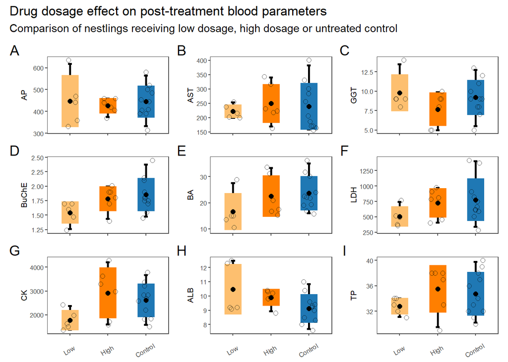

```r
## Drug dosage groups (low versus high) data
## -----------------------------------------------------------------------------
g1 + g2 + g3 + g4 + g6 + g7 + g8 + g9 + g10 + plot_annotation(tag_levels = 'A', title="Drug dosage effect on post-treatment blood parameters", subtitle="Comparison of nestlings receiving low dosage, high dosage or untreated control") &
  theme(plot.tag = element_text(size = 14))
```

```r
ggsave(filename = "figures/BloodDosageMultiplot.png", device = "png", dpi = 300,
       width = 6, height = 6, units = "in")
```